# Grid Modernization Engine: knowledge base

NSF Regional Innovation Engines, Cohort 2. Technology profile v3.1. Draft, in progress

**NSF Grid Modernization Engine in the Carolinas**, led by University of North Carolina at Charlotte. NSF award 2532380, start August 2026. Search window for papers and patents: from August 2021 (five years before the award) onward.

## At a glance

| Measure | Value |
| --- | --- |
| People named by NSF or the Engine’s site | 10 |
| of them active researchers (>= 5 works since window start) | 2 |
| Team members who are inventors (2021-2025 grants, in the region) | 1 |
| Partners (site list + team members’ organisations) | 3 |
| Knowledge-producer partners (universities, labs, institutes) | 0 |
| Partner papers in the Engine’s topics | 0 |
| of them with an in-region partner | 0 |
| Regional patents in the technology profile (2021-2025 grants) | 442 |
| Location quotient of the technology profile (patents) | 1.9 |
| Share of regional technology patents owned by partners | 0.0% |

## Economic base

| NAICS | Industry | Employment in region | Establishments | Share of US employment | Employment LQ |
| --- | --- | --- | --- | --- | --- |
| 2211 | Electric power generation, transmission and distribution | 28,643 | 761 | 5.5% | 1.21 |
| 3353 | Electrical equipment manufacturing | 12,110 | 75 | 9.6% | 2.12 |
| 3359 | Other electrical equipment and components | 11,290 | 103 | 7.4% | 1.63 |

Industries related to the Engine’s technology (chosen from the NSF abstract, see `data/manual/engine_naics.csv`). County Business Patterns 2023; LQ = the industry’s share of regional employment relative to its share of US employment (1 = US average). Region: whole state(s).

## Technology profile

Version 3.1, core. The NSF abstract names 4 technologies of this Engine (scientific and technical fragments extracted with a fixed prompt; the extraction was done by hand in a chat session, not reproducible). For each technology, all 4,516 OpenAlex topics and all CPC main groups are ranked by several independent signals; the core keeps up to 2 topics and 2 CPC main groups per technology. *Judge*: chosen by a rubric judge where no candidate was confirmed by two kinds of evidence (also by hand in a chat session). An empty cell: no suitable item among the candidates. See Methodology and the comparison of versions.

| # | Technology | OpenAlex topics | CPC main groups |
| --- | --- | --- | --- |
| 1 | electric grid transmission, distribution and automation | T12451 Smart Grid and Power Systems T14502 High-Voltage Power Transmission Systems | H02J13/00 Circuit arrangements for providing remote monitoring or remote control of equipment in a power distribution network H02J3/00 Circuit arrangements for AC mains or AC distribution networks |
| 2 | solid state and hybrid transformers, inverters | T10228 Multilevel Inverters and Converters T10175 Advanced DC-DC Converters | H01F38/00 Adaptations of transformers or inductances for specific applications or functions H01F27/00 Details of transformers or inductances, in general |
| 3 | nuclear construction | T13808 Construction Engineering and Safety (judge) T10597 Nuclear reactor physics and engineering (judge) | G21C21/00 Apparatus or processes specially adapted to the manufacture of reactors or parts thereof |
| 4 | grid cybersecurity | T10917 Smart Grid Security and Resilience T12451 Smart Grid and Power Systems | Y04S40/00 Systems for electrical power generation, transmission, distribution or end-user application management characterised by the use of communication or information technologies, or communication… |

## People

| Role | People |
| --- | --- |
| organizer | 7 |
| researcher | 3 |

| Name | Role | On NSF award | Title | Organisation | Works since window (in Engine topics) | h-index | Patents 2021-25 (in Engine profile) | Site | OpenAlex |
| --- | --- | --- | --- | --- | --- | --- | --- | --- | --- |
| John Daniels | researcher | PI | Chief Executive Officer, PI |  | 28 (0) | 18 |  | [page](https://carolinasgridengine.com/about-us/) | [profile](https://openalex.org/A5088910249) |
| Ramtin Hadidi | researcher | Co-PI | Co-Chief Technology Officer, co-PI |  | - | - |  | [page](https://carolinasgridengine.com/about-us/) |  |
| Robert Cox | researcher | Co-PI | Co-Chief Technology Officer, co-PI |  | 10 (0) | 59 | 1 (1) | [page](https://carolinasgridengine.com/about-us/) | [profile](https://openalex.org/A5062395162) |
| Catherine Hayes | organizer | Co-PI | Director, Cross-Sector Partnerships, co-PI |  | - | - |  | [page](https://carolinasgridengine.com/about-us/) |  |
| Cristina Paredes | organizer |  | Executive Director | SC Nexus | - | - |  | [page](https://carolinasgridengine.com/about-us/) |  |
| Greg Needham | organizer | Co-PI | Chief Operations Officer, co-PI |  | - | - |  | [page](https://carolinasgridengine.com/about-us/) |  |
| Jeffrey Merrifield | organizer |  | Partner | Pillsbury Winthrop Shaw Pittman LLP | - | - |  | [page](https://carolinasgridengine.com/about-us/) |  |
| Jennifer Mundt | organizer |  | Assistant Secretary of Clean Energy Economic Development | North Carolina Department of Commerce | - | - |  | [page](https://carolinasgridengine.com/about-us/) |  |
| John Hardin | organizer |  | Executive Director, Office of Science, Technology & Innov… | North Carolina Department of Commerce | - | - |  | [page](https://carolinasgridengine.com/about-us/) |  |
| Stacey Moore | organizer |  | Director, Workforce Development |  | - | - |  | [page](https://carolinasgridengine.com/about-us/) |  |

Publication counts are shown only where the OpenAlex author matches both the name and the person’s current organisation. The OpenAlex link is given only for these reliable matches, and not for profiles flagged as possibly merging several namesakes. *Site* links to the page of the Engine’s website where the person is named. Click a number of works to see the list on the Publications page. *Patents*: US grants 2021-2025 with the person among the inventors (same last and first name, address in the Engine’s states); click the number for the list on the Patents page. In brackets: works in the Engine’s topics, patents with a CPC code in the Engine’s technology profile.

## Researchers at partner organisations

No knowledge-producer partner in the Engine’s states with works in its topics.

## Partners

| Organisation class | Partners |
| --- | --- |
| company | 1 |
| government | 1 |
| intermediary | 1 |

Partner list on the site: *Not available: the page reports “100+ committed partners” without names; only governance board organisations are named*.

| Partner | Class | State | OpenAlex works since window (all topics) |
| --- | --- | --- | --- |

## Science base: partner papers in the Engine’s topics

```
## No knowledge-producer partners with an OpenAlex institution record.
```

## Technology base: patents

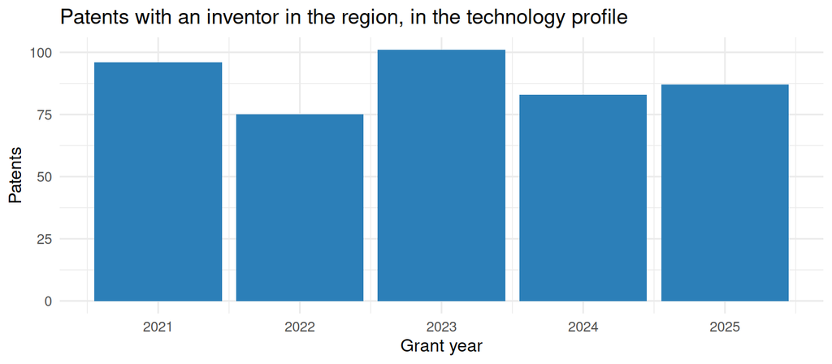

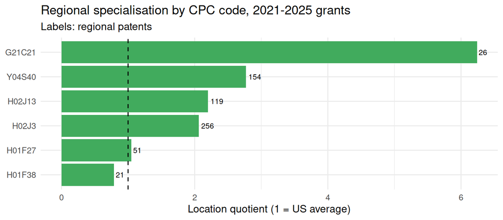

| Assignee | Regional patents in profile |
| --- | --- |
| Causam Enterprises, Inc. | 49 |
| Digital Global Systems, Inc. | 39 |
| ABB Schweiz AG | 20 |
| General Electric Company | 18 |
| DIGITAL GLOBAL SYSTEMS, INC. | 13 |
| EATON INTELLIGENT POWER LIMITED | 12 |
| Hitachi Energy Switzerland AG | 12 |
| Westinghouse Electric Company LLC | 11 |
| CAUSAM EXCHANGE, INC. | 10 |
| KOOLBRIDGE SOLAR, INC. | 10 |

Partner-owned patents invented in the region: 0, of which 0 (NA) fall in the Engine’s technology profile.

## Competition

With 442 patents in the technology profile (2021-2025 grants), the Engine’s region would rank **3** among US states; its specialisation (LQ) is 1.901.

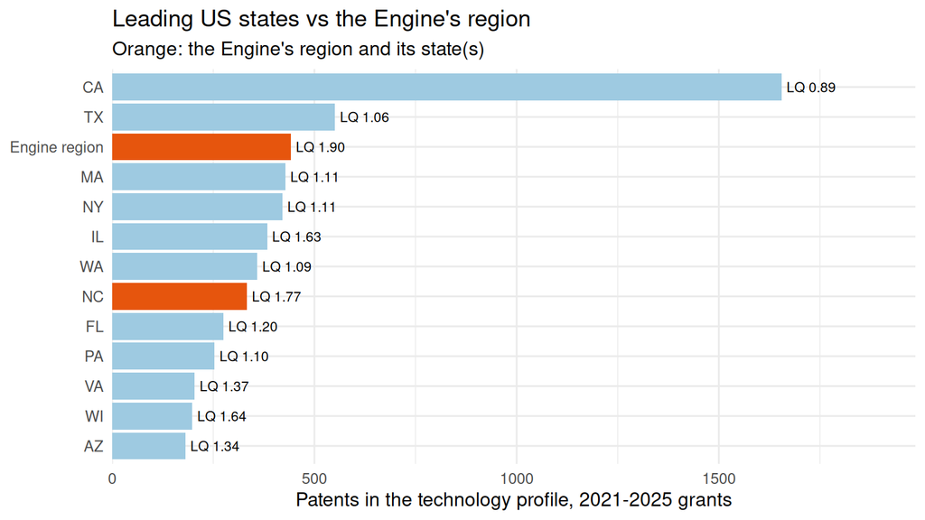

| Country | Share of US patents in profile | Share of world papers in topics |
| --- | --- | --- |
| US | 40.6% | 10.3% |
| JP | 19.9% | 2.3% |
| CN | 9.4% | 28.7% |
| KR | 7.0% | 2.1% |
| DE | 6.4% | 2.3% |
| TW | 3.3% | NA |
| GB | 2.3% | 2.4% |
| CA | 2.0% | 2.1% |
| IL | 2.0% | NA |
| IN | 2.0% | 10.2% |

Patents: inventor countries on US grants in the profile (a patent counts for every country of its inventors). Papers: author countries of OpenAlex works in the Engine’s topics since the window start.

## Data and limitations

- People: PIs and Co-PIs from the NSF Award API; leadership listed on the Engine’s website. Roles come from titles and organisations, revised with OpenAlex evidence.
- Partners: as listed on the Engine’s website, plus organisations of team members. Some Engines publish partner logos without names.
- Region: the Engine’s counties where the list is known (NEO-SMART: 18 Northeast Ohio counties; STELLAR: 11 counties from the NSF abstract), otherwise its states (state-level proxy).
- Technology profile: v3.1 (switch versions in the header). Partner papers and regional patents depend on it: v1 uses mostly CPC subclasses, the v3.1 core uses CPC main groups, which are narrower, so it counts fewer patents and the LQ of a small region rests on few patents.
- Papers: OpenAlex; partner papers are restricted to the Engine’s OpenAlex topics.
- Patents: USPTO grants 2021-2025; inventor locations from PatentsView; pre-grant publications are not included.